# HW_1

# Number 4

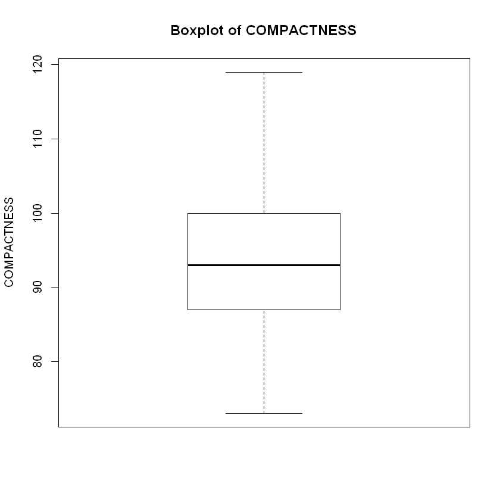

```r
#Boxplot
boxplot(dataset$V1,main="Boxplot of COMPACTNESS", ylab = "COMPACTNESS")
```

### Analysis:

Q1 and Q4 both vary in compactness but it seems that the compactness amongst all cars in Q4 all tend to have a longer range. In Q2 and Q3 they tend to vary a lot less with Q2 and Q3 hanging around the median. The cars tend to have a standard size.

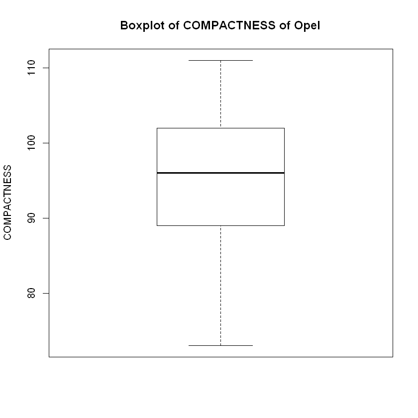

```r
boxplot(opel_hist_data$V1,main="Boxplot of COMPACTNESS of Opel", ylab = "COMPACTNESS")
```

### Analysis:

Quartile group 1 is extended. The compactness for opel has a wider range in the lower numbers. The positive quartile group also vary in compactness but not as much.

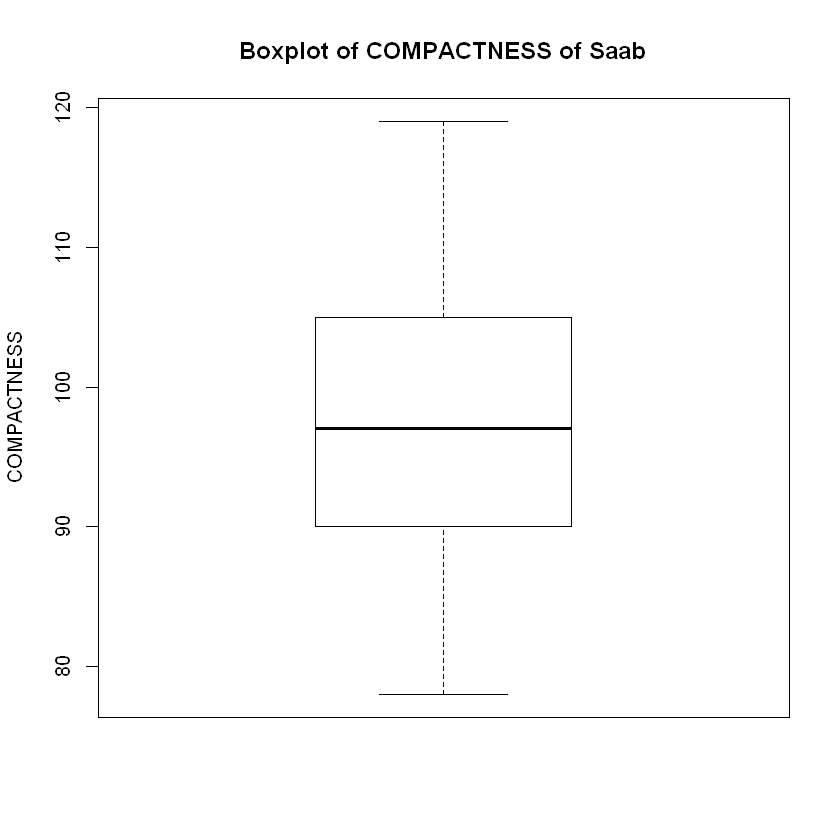

```r
boxplot(saab_hist_data$V1,main="Boxplot of COMPACTNESS of Saab", ylab = "COMPACTNESS")
```

### Analysis:

The compactness for Saab seems symmetrical with Q1 and Q4 ranging within the same size. Q2 and Q3 are split between the median about the same but with Q3 ranging slightly more

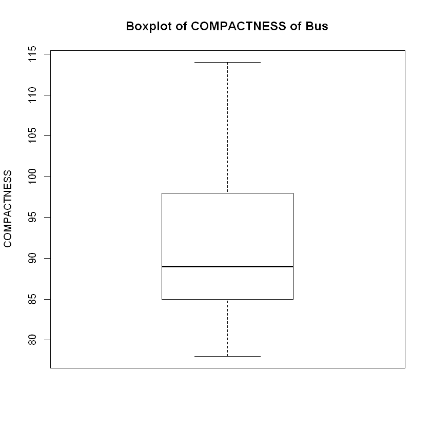

```r
boxplot(bus_hist_data$V1,main="Boxplot of COMPACTNESS of Bus", ylab = "COMPACTNESS")
```

### Analysis:

In Q1 and Q2 the compactness of bus seems to vary much less. Most buses have the same compactness around this range but past the median the compact of bus is vary way more in Q3 and Q4.

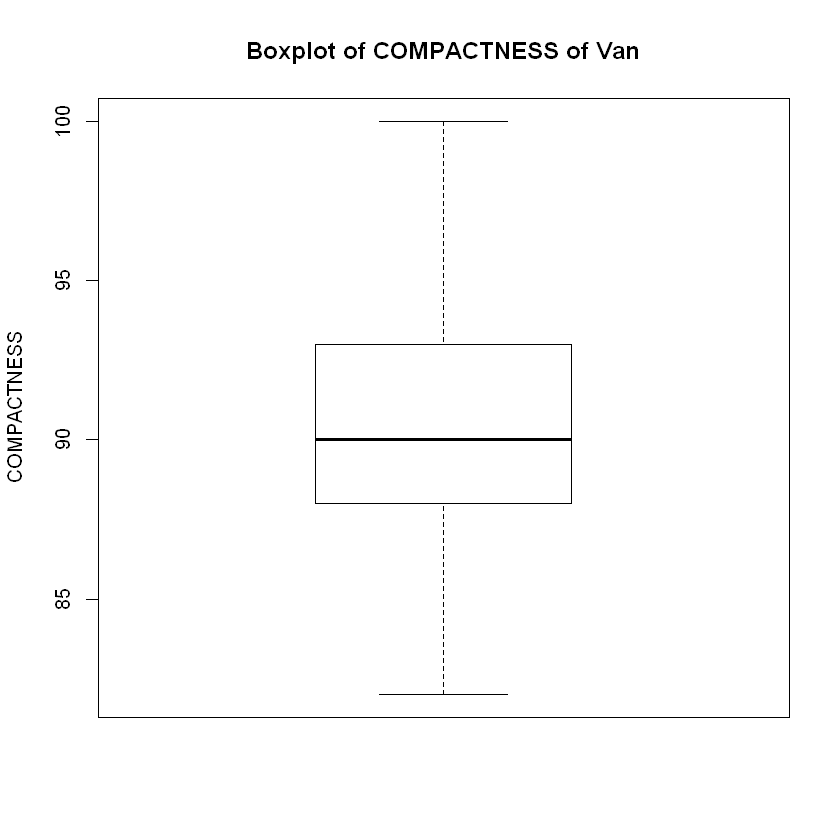

```r
boxplot(van_hist_data$V1,main="Boxplot of COMPACTNESS of Van", ylab = "COMPACTNESS")
```

### Analysis

This boxplot seems very symmetrical. Q1 and Q4 are comparatively the same range and will vary a lot in compactness. In Q2 and Q3 the compact doesn’t as much as but does range more in Q3.

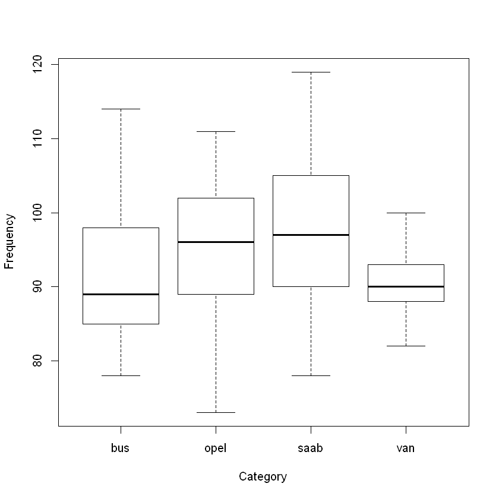

```r
boxplot(V1~V19, data = selected_data, xlab = "Category", ylab = "Frequency")
```

# Number 5

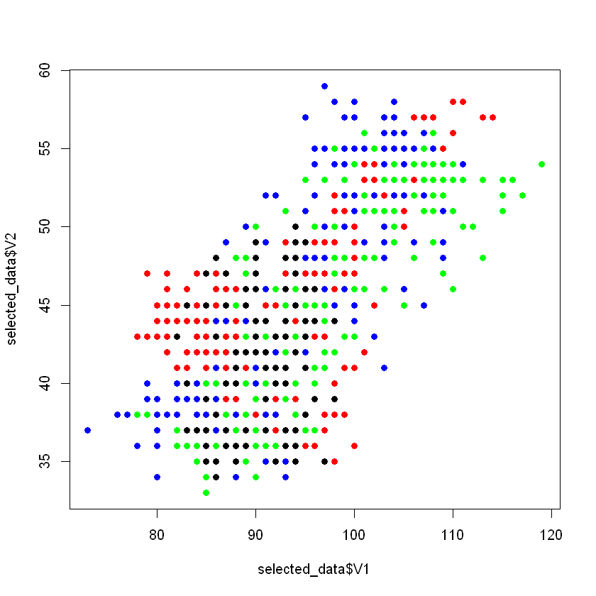

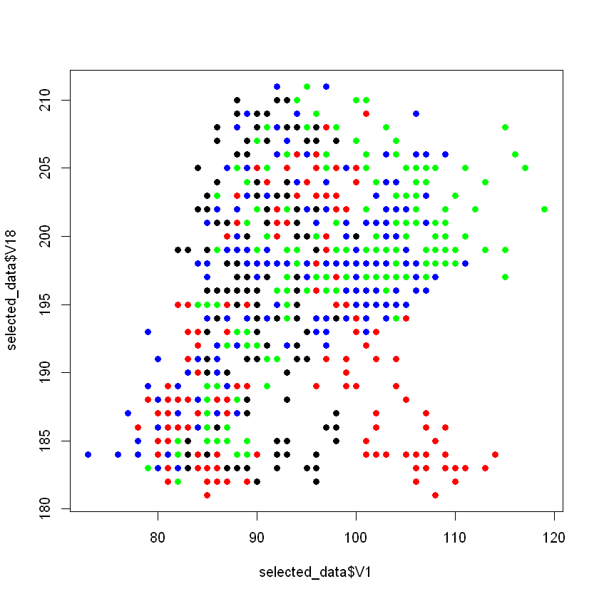

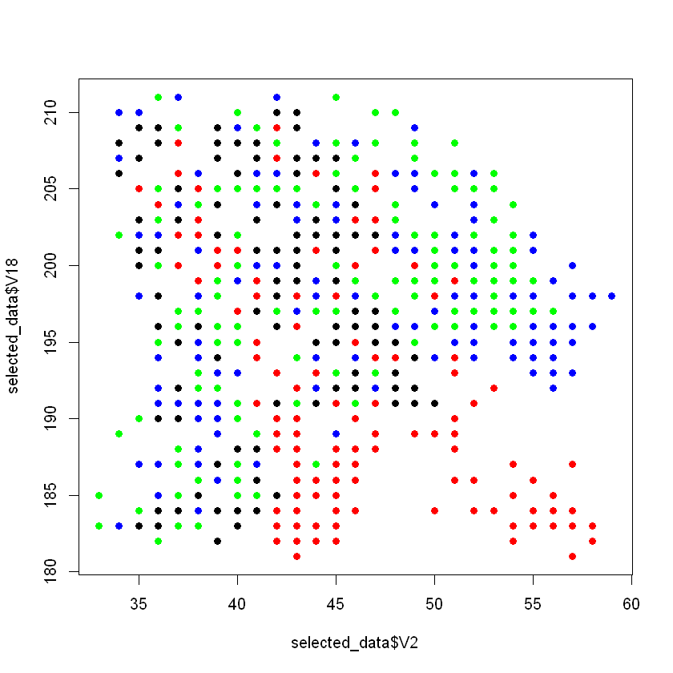

```r
# Supervised scatter
plot(selected_data$V1, selected_data$V2, col=c("red","blue","green","black")[dataset$V19],pch=19)
plot(selected_data$V1, selected_data$V18, col=c("red","blue","green","black")[dataset$V19],pch=19)
plot(selected_data$V2, selected_data$V18, col=c("red","blue","green","black")[dataset$V19],pch=19)
```